# Homework 03

## Question 1: Build an `explain-to-me` skill

Create a small skill named `explain-to-me` that helps you understand a homework question.

1. Design your `SKILL.md` file so that, when you explicitly ask your agent to use the skill to read a homework question, the agent communicates with you and explains what the question is asking.
2. Keep the skill file short. It should contain a few useful rules, instructions, and a clear statement of your intent. For example, you may ask the agent to explain the goal of the question, clarify what work is required, and point you to an appropriate section of the Week 3 lectures: [Ridge Regression: Stability Through Shrinkage](https://teazrq.github.io/stat432rpy/topics/ridge-regression/ridge-regression.html) or [From a Penalized Objective to a Fitted Ridge Model](https://teazrq.github.io/stat432rpy/topics/ridge-regression/optimization-and-cross-validation.html). The skill should help you understand the question without completing the solution for you.
3. Create the skill yourself or with the help of AI. Save it as `explain-to-me/SKILL.md`. Then ask your AI agent to install the skill using its normal skill-installation method. Test it by explicitly asking the agent to use `explain-to-me` to read and explain Question 2.
4. If the skill does not work well, or if it begins to disturb your usual workflow, ask your agent to remove the installed skill. You may revise and reinstall it if you wish.
5. In all cases, append the complete contents of your developed `explain-to-me/SKILL.md` file at the end of your Homework 3 submission under the heading **`explain-to-me` skill**.

## Question 2: Ridge regression with nearly collinear predictors

Let $n=100$. Generate mutually independent standard normal random variables

$$L_i, U_{i1}, U_{i2}, X_{i3}, X_{i4},
\qquad i=1,\ldots,n,$$

and define

$$X_{i1}=L_i+0.04U_{i1},
\qquad
X_{i2}=L_i+0.04U_{i2}.$$

Center and standardize each column of $\mathbf X$ to have mean zero and average squared value one, following the [lecture’s scaling convention](https://teazrq.github.io/stat432rpy/topics/ridge-regression/ridge-regression.html#put-every-covariate-on-a-common-scale).

Continue to use $\mathbf X\in\mathbb R^{n\times p}$ for the standardized matrix and keep it fixed throughout the question, where $p=4$ is the number of predictors. The unpenalized intercept gives $p+1=5$ total fitted coefficients. Let

$$\boldsymbol\beta
=
(1.5,1.5,1,0)^{\mathsf T},
\qquad
\boldsymbol\mu
=
\mathbf X\boldsymbol\beta.$$

Generate a training response and an independent test response at the same predictor values:

$$\begin{aligned}
\mathbf y
&=
\boldsymbol\mu+\boldsymbol\epsilon,\\
\mathbf y^*
&=
\boldsymbol\mu+\boldsymbol\epsilon^*,
\end{aligned}$$

where

$$\boldsymbol\epsilon,
\boldsymbol\epsilon^*
\overset{\mathrm{ind}}{\sim}
\mathcal N_n(\mathbf0,\mathbf I_n).$$

Center the training response as $\widetilde{\mathbf y}=\mathbf y-\bar y\mathbf1_n$. For each $\lambda\in\{0,0.02,0.2\}$, fit the slopes using the lecture’s ridge formula:

$$\widehat{\boldsymbol\beta}_\lambda
=
\left(\mathbf X^{\mathsf T}\mathbf X+n\lambda\mathbf I_p\right)^{-1}
\mathbf X^{\mathsf T}\widetilde{\mathbf y}.$$

The unpenalized intercept is $\widehat\beta_0=\bar y$; add this training mean back when predicting either response. The case $\lambda=0$ is ordinary least squares. Use seed `43231` before generating the design and responses. R and Python use different random-number generators, so their exact numerical results need not agree.

1. Generate $\mathbf X$ once. Report the correlation between its first two columns and its largest and smallest singular values. Use these quantities to explain why the estimator contrast $\widehat\beta_1-\widehat\beta_2$ should be much more variable than $\widehat\beta_1+\widehat\beta_2$.
2. Independently repeat the generation of $\mathbf y$ and $\mathbf y^*$, followed by all three fits, 200 times while keeping $\mathbf X$ fixed. Draw the training and test noise inside each repetition, then reuse that realized pair for all three values of $\lambda$. For each value of $\lambda$, report the empirical mean and standard deviation of

$$\widehat\beta_1,
\quad
\widehat\beta_2,
\quad
\widehat\beta_1+\widehat\beta_2,
\quad
\widehat\beta_1-\widehat\beta_2.$$

Also report the average training MSE and the average test MSE calculated from the independent test response, where

$$\operatorname{MSE}_{\mathrm{test}}
=
\frac{1}{n}
\left\lVert
\mathbf y^*
-
\widehat\beta_0\mathbf1_n
-
\mathbf X\widehat{\boldsymbol\beta}
\right\rVert_2^2.$$

3. Interpret the coefficient estimates and test MSE using bias and variance. Explain why ridge can substantially stabilize the individual coefficients without producing an equally large change in the fitted values.

### My answer

**Show the workflow**

```python
import numpy as np

rng = np.random.default_rng(43231)
n = 100

L  = rng.normal(size=n)
U1 = rng.normal(size=n)
U2 = rng.normal(size=n)
X3 = rng.normal(size=n)
X4 = rng.normal(size=n)
X1 = L + 0.04 * U1
X2 = L + 0.04 * U2

X = np.column_stack([X1, X2, X3, X4])
X = X - X.mean(0)
X = X / np.sqrt((X ** 2).mean(0))   # mean 0, average squared value 1
p = 4
beta = np.array([1.5, 1.5, 1.0, 0.0])
mu = X @ beta

# part a
corr12 = np.corrcoef(X[:, 0], X[:, 1])[0, 1]
sv = np.linalg.svd(X, compute_uv=False)
print(f"corr(X1,X2) = {corr12:.4f}")
print(f"largest sv = {sv.max():.3f}, smallest sv = {sv.min():.3f}, cond = {sv.max()/sv.min():.1f}")

# part b
lambdas = [0.0, 0.02, 0.2]
reps = 200
XtX = X.T @ X
rec = {lam: {k: [] for k in ["b1", "b2", "sum", "diff", "tr", "te"]} for lam in lambdas}
for _ in range(reps):
    y = mu + rng.normal(size=n)
    ystar = mu + rng.normal(size=n)
    ybar = y.mean()
    yt = y - ybar
    Xty = X.T @ yt
    for lam in lambdas:
        b = np.linalg.solve(XtX + n * lam * np.eye(p), Xty)
        rec[lam]["b1"].append(b[0]); rec[lam]["b2"].append(b[1])
        rec[lam]["sum"].append(b[0] + b[1]); rec[lam]["diff"].append(b[0] - b[1])
        rec[lam]["tr"].append(np.mean((y - ybar - X @ b) ** 2))
        rec[lam]["te"].append(np.mean((ystar - ybar - X @ b) ** 2))

print("\nlam   b1 mean(sd)    b2 mean(sd)    b1+b2 mean(sd)  b1-b2 mean(sd)   trMSE  teMSE")
for lam in lambdas:
    s = rec[lam]
    f = lambda k: f"{np.mean(s[k]):.3f}({np.std(s[k]):.3f})"
    print(f"{lam:<5} {f('b1'):<14} {f('b2'):<14} {f('sum'):<15} {f('diff'):<15} "
          f"{np.mean(s['tr']):.3f}  {np.mean(s['te']):.3f}")
```

```
corr(X1,X2) = 0.9983
largest sv = 14.173, smallest sv = 0.406, cond = 34.9

lam   b1 mean(sd)    b2 mean(sd)    b1+b2 mean(sd)  b1-b2 mean(sd)   trMSE  teMSE
0.0   1.290(1.791)   1.701(1.793)   2.992(0.105)    -0.411(3.583)   0.949  1.038
0.02  1.465(0.144)   1.497(0.148)   2.961(0.104)    -0.032(0.273)   0.960  1.029
0.2   1.355(0.049)   1.359(0.050)   2.715(0.095)    -0.004(0.029)   1.064  1.125
```

**a.** The two columns are almost the same vector since both are $L$ plus a tiny independent wiggle, and the correlation comes out around $0.998$. The design’s largest singular value is about $14.2$ and the smallest about $0.41$ (condition number roughly $35$). The near-collinearity means one singular direction, the $\mathbf x_1-\mathbf x_2$ contrast, has a tiny singular value, and OLS variance blows up along small-singular-value directions. So $\widehat\beta_1-\widehat\beta_2$ (which lives in that squished direction) is way more variable than $\widehat\beta_1+\widehat\beta_2$ (which lives in the big-singular-value direction the data pin down well).

**b.** The table above prints the mean and sd of each quantity plus the average train/test MSE. The pattern: at $\lambda=0$ the individual coefficients and especially $\widehat\beta_1-\widehat\beta_2$ have huge sd (around $3.6$), while $\widehat\beta_1+\widehat\beta_2$ is tight (sd about $0.1$). Ridge crushes the variance of the difference (sd drops to about $0.27$ at $\lambda=0.02$ and $0.03$ at $\lambda=0.2$) while barely touching the sum.

**c.** OLS is basically unbiased here, but the collinearity makes it high-variance in the contrast direction, so on any single dataset $\widehat\beta_1$ and $\widehat\beta_2$ can be wildly off in opposite directions even though they add up correctly. Ridge trades a little bias for a big variance cut. The reason the coefficients stabilize a lot but the fitted values move only a little is that the unstable direction is exactly the low-singular-value direction, which contributes almost nothing to $\mathbf X\widehat{\boldsymbol\beta}$. Shrinking a direction the data barely see removes a lot of coefficient noise without changing predictions much, which is why the test MSE at $\lambda=0.02$ actually edges below OLS. Push $\lambda$ to $0.2$ and the sum shrinks noticeably below its true value of $3$, and that added bias pushes test MSE back up.

## Question 3: What does ridge regression shrink?

Let $\mathbf X\in\mathbb R^{n\times p}$ be a centered predictor matrix, and let $\widetilde{\mathbf y}\in\mathbb R^n$ be the centered response. Use the supplied predictor scales for this algebraic question; the columns need not have unit variance. Here $p$ counts predictors, $\boldsymbol\beta\in\mathbb R^p$ contains their slopes, and $p+1$ counts all fitted coefficients, including the separately fitted, unpenalized intercept. Ridge regression minimizes

$$L_\lambda(\boldsymbol\beta)
=
\frac{1}{2n}
\left\lVert
\widetilde{\mathbf y}-\mathbf X\boldsymbol\beta
\right\rVert_2^2
+
\frac{\lambda}{2}
\lVert\boldsymbol\beta\rVert_2^2.$$

1. Derive the ridge normal equation

$$\left(
\mathbf X^{\mathsf T}\mathbf X
+n\lambda\mathbf I_p
\right)
\widehat{\boldsymbol\beta}_\lambda
=
\mathbf X^{\mathsf T}\widetilde{\mathbf y}.$$

Explain why it has a unique solution whenever $\lambda>0$, even if $\mathbf X$ is rank deficient or $p>n$.

2. Let

$$\mathbf X
=
\mathbf U_r\mathbf D_r\mathbf V_r^{\mathsf T}$$

be a compact singular value decomposition, where $r=\operatorname{rank}(\mathbf X)$, $\mathbf U_r\in\mathbb R^{n\times r}$, $\mathbf D_r\in\mathbb R^{r\times r}$, and $\mathbf V_r\in\mathbb R^{p\times r}$. Show that ridge multiplies the fitted response component in the $j$th left singular-vector direction, for $j=1,\ldots,r$, by

$$\rho_j(\lambda)
=
\frac{d_j^2}{d_j^2+n\lambda}.$$

Suppose $n=100$, $\lambda=0.01$, and the nonzero singular values are

$$d_1=10,
\qquad
d_2=2,
\qquad
d_3=0.2.$$

Calculate the three shrinkage factors and the total effective degrees of freedom, including the unpenalized intercept:

$$\operatorname{df}_{\mathrm{eff}}(\lambda)
=
1+\sum_{j=1}^3\rho_j(\lambda).$$

3. Which direction receives the strongest shrinkage? Explain why shrinking this direction can reduce prediction variance. Under what circumstance could the same shrinkage produce substantial prediction bias?

### My answer

**a.** Differentiate the objective:
$$\nabla L_\lambda(\boldsymbol\beta)
= \frac{1}{n}\mathbf X^{\mathsf T}(\mathbf X\boldsymbol\beta - \widetilde{\mathbf y}) + \lambda\boldsymbol\beta.$$
Set it to zero and multiply by $n$:
$$\mathbf X^{\mathsf T}\mathbf X\boldsymbol\beta - \mathbf X^{\mathsf T}\widetilde{\mathbf y} + n\lambda\boldsymbol\beta = \mathbf 0
\;\Longrightarrow\;
(\mathbf X^{\mathsf T}\mathbf X + n\lambda\mathbf I_p)\widehat{\boldsymbol\beta}_\lambda = \mathbf X^{\mathsf T}\widetilde{\mathbf y}.$$
$\mathbf X^{\mathsf T}\mathbf X$ is symmetric positive semidefinite, so its eigenvalues are $\ge 0$. Adding $n\lambda\mathbf I_p$ with $\lambda>0$ bumps every eigenvalue up by $n\lambda>0$, making the matrix positive definite and therefore invertible. That holds no matter what, even if $\mathbf X$ is rank deficient or $p>n$, so the solution is unique.

**b.** Plug the compact SVD $\mathbf X = \mathbf U_r\mathbf D_r\mathbf V_r^{\mathsf T}$ into the ridge solution. Using $\mathbf V_r^{\mathsf T}\mathbf V_r = \mathbf I_r$,
$$\widehat{\boldsymbol\beta}_\lambda
= (\mathbf X^{\mathsf T}\mathbf X + n\lambda\mathbf I_p)^{-1}\mathbf X^{\mathsf T}\widetilde{\mathbf y}
= \mathbf V_r(\mathbf D_r^2 + n\lambda\mathbf I_r)^{-1}\mathbf D_r\mathbf U_r^{\mathsf T}\widetilde{\mathbf y},$$
so the fitted values are
$$\widehat{\mathbf y} = \mathbf X\widehat{\boldsymbol\beta}_\lambda
= \mathbf U_r\mathbf D_r(\mathbf D_r^2 + n\lambda\mathbf I_r)^{-1}\mathbf D_r\mathbf U_r^{\mathsf T}\widetilde{\mathbf y}
= \sum_{j=1}^r \mathbf u_j\,\frac{d_j^2}{d_j^2 + n\lambda}\,(\mathbf u_j^{\mathsf T}\widetilde{\mathbf y}).$$
Each left-singular component $\mathbf u_j^{\mathsf T}\widetilde{\mathbf y}$ gets multiplied by $\rho_j(\lambda) = d_j^2/(d_j^2 + n\lambda)$. At $\lambda=0$ every factor is $1$ (that’s OLS on the column space); larger $\lambda$ pulls each factor toward $0$.

With $n\lambda = 100(0.01) = 1$:
$$\rho_1 = \frac{100}{101} \approx 0.9901,\quad
\rho_2 = \frac{4}{5} = 0.8,\quad
\rho_3 = \frac{0.04}{1.04} \approx 0.0385.$$
$$\operatorname{df}_{\mathrm{eff}} = 1 + 0.9901 + 0.8 + 0.0385 \approx 2.83.$$

**c.** The third direction ($d_3 = 0.2$) gets shrunk the hardest, from $1$ down to about $0.04$. Small singular values mean that direction is barely represented in $\mathbf X$, so its OLS coefficient is estimated with huge variance (variance scales like $1/d_j^2$). Damping it removes most of that noise, which lowers prediction variance. The catch: if the true mean $\boldsymbol\mu$ actually has real signal lined up with that low-singular-value direction, then shrinking it toward zero throws away genuine structure and introduces real bias. Ridge helps when the weak directions are mostly noise and hurts when they carry signal.

## Question 4: Ridge regression and optimization

Let $\mathbf X\in\mathbb R^{n\times p}$ be a centered predictor matrix with $p=2$. Its columns need not have unit variance in this question. The intercept is fitted separately and is not penalized. Suppose the two eigenvalues of

$$\mathbf A_0
=
\frac{1}{n}\mathbf X^{\mathsf T}\mathbf X$$

are $9$ and $0.01$. Ridge regression with $\lambda=0.09$ has curvature matrix

$$\mathbf A_\lambda
=
\frac{1}{n}\mathbf X^{\mathsf T}\mathbf X
+
\lambda\mathbf I_p.$$

1. Calculate the condition numbers of $\mathbf A_0$ and $\mathbf A_\lambda$. Explain what the change says about the geometry of the ridge objective.
2. Gradient descent uses

$$\boldsymbol\beta^{(k+1)}
=
\boldsymbol\beta^{(k)}
-
\eta\nabla L_\lambda\!\left(\boldsymbol\beta^{(k)}\right).$$

Let $\widehat{\boldsymbol\beta}_\lambda$ be the ridge minimizer and define the optimization error

$$\mathbf e^{(k)}
=
\boldsymbol\beta^{(k)}
-
\widehat{\boldsymbol\beta}_\lambda.$$

Show that the component of $\mathbf e^{(k)}$ in an eigendirection with unpenalized eigenvalue $a$ is multiplied at each step by

$$1-\eta(a+\lambda).$$

Let $M=9.09$, the largest eigenvalue of $\mathbf A_\lambda$. Find the interval of step sizes that contracts every eigendirection. Then compare these two choices:

- For $\eta=1/M$, calculate the two contraction factors and explain which direction converges faster.
- For $\eta=2.1/M$, determine whether the method converges. Assume the initial error has a nonzero component in the eigendirection corresponding to $M$.
3. Increasing $\lambda$ generally improves the condition number. Explain why choosing $\lambda$ to make gradient descent converge as quickly as possible is not a valid statistical tuning rule.

### My answer

**a.** The condition number is the ratio of largest to smallest eigenvalue. For $\mathbf A_0$ the eigenvalues are $9$ and $0.01$, so
$$\kappa(\mathbf A_0) = \frac{9}{0.01} = 900.$$
Adding $\lambda = 0.09$ shifts both eigenvalues up by $0.09$, giving $9.09$ and $0.10$, so
$$\kappa(\mathbf A_\lambda) = \frac{9.09}{0.10} = 90.9.$$
The ridge objective is still more curved along one axis than the other, but far less lopsided. Geometrically the contours go from very stretched ellipses to much rounder ones, which is what makes gradient descent behave better.

**b.** The gradient is $\nabla L_\lambda(\boldsymbol\beta) = \mathbf A_\lambda\boldsymbol\beta - \frac1n\mathbf X^{\mathsf T}\widetilde{\mathbf y}$, and at the minimizer $\mathbf A_\lambda\widehat{\boldsymbol\beta}_\lambda = \frac1n\mathbf X^{\mathsf T}\widetilde{\mathbf y}$. Subtracting,
$$\mathbf e^{(k+1)}
= \boldsymbol\beta^{(k)} - \eta\nabla L_\lambda(\boldsymbol\beta^{(k)}) - \widehat{\boldsymbol\beta}_\lambda
= (\mathbf I_p - \eta\mathbf A_\lambda)\mathbf e^{(k)}.$$
In an eigendirection of $\mathbf A_0$ with eigenvalue $a$, $\mathbf A_\lambda$ has eigenvalue $a+\lambda$, so that component of the error is multiplied by $1 - \eta(a+\lambda)$ each step.

Every direction contracts when $|1 - \eta(a+\lambda)| < 1$ for both eigenvalues. The binding one is the largest, $M = 9.09$, giving
$$0 < \eta < \frac{2}{M} = \frac{2}{9.09} \approx 0.2200.$$

For $\eta = 1/M = 1/9.09$: - strong direction ($9.09$): $1 - \frac{9.09}{9.09} = 0$. - weak direction ($0.10$): $1 - \frac{0.10}{9.09} \approx 0.989$.

The strong direction collapses in a single step, while the weak direction crawls in at rate $0.989$ per step. So the small-eigenvalue direction is the bottleneck, and it converges much slower.

For $\eta = 2.1/M$: the strong-direction factor is $1 - 2.1 = -1.1$. Its magnitude exceeds $1$, so a nonzero error component there flips sign and grows every step. The method does not converge.

**c.** Bigger $\lambda$ does make the problem better conditioned and gradient descent faster, but $\lambda$ is a statistical knob, not an optimization one. It controls how much you shrink the coefficients, which sets the bias-variance tradeoff and the predictive behavior of the fitted model. Tuning it for fast convergence would just push you toward heavy shrinkage regardless of whether that model predicts well, optimizing the wrong thing. $\lambda$ should be chosen by something like cross-validation or GCV that targets prediction error; the optimizer’s step size $\eta$ is the free parameter you’d tune for speed.

## Question 5: Selecting the ridge penalty for real-estate prediction

The supplied `data/realestate.csv` contains 414 real-estate transactions from Sindian District, New Taipei City, Taiwan. The quantitative response `price` is the unit house price. The six predictors are the transaction date, house age, distance to the nearest mass rapid transit station, number of nearby convenience stores, latitude, and longitude. Treat all six predictors as quantitative in this question. The column `row_id` identifies an observation and must not be used as a predictor.

The file `data/realestate-split-folds.csv` assigns 332 observations to the training set and 82 observations to the final test set. It also gives ten fold labels for the training observations. Match the two files using `row_id` and do not use the test responses while selecting a model.

Use the penalty grid

$$\Lambda
=
\{0\}
\mathbin{\cup}
\left\{
10^{-4+0.05l}:l=0,\ldots,120
\right\}.$$

For every fit, center and standardize each predictor using only the observations available to that fit, with the variance divided by the number of fitting observations. Center the response and leave the intercept unpenalized.

1. Perform ten-fold cross-validation over $\Lambda$ using the supplied training folds. Estimate the predictor means and scales separately within each set of nine training folds. For each $\lambda$, calculate the mean validation MSE and $\operatorname{SE}(\lambda)$, the sample standard deviation of the ten fold errors divided by $\sqrt{10}$. Use this SE for the conventional one-standard-error heuristic. Plot the mean validation MSE and identify $\lambda_{\min}$. Choose $\lambda_{\mathrm{1se}}$ as the largest candidate in $\Lambda$, including OLS, satisfying

$$\overline{\operatorname{MSE}}(\lambda)
\leq
\overline{\operatorname{MSE}}(\lambda_{\min})
+
\operatorname{SE}(\lambda_{\min}).$$

2. Use all $n=332$ training observations to calculate the [lecture’s GCV criterion](https://teazrq.github.io/stat432rpy/topics/ridge-regression/optimization-and-cross-validation.html#loocv-and-gcv) for each $\lambda\in\Lambda$:

$$\operatorname{GCV}(\lambda)
=
\frac{
\operatorname{MSE}_{\mathrm{train}}(\lambda)
}{
\left\{
1-\operatorname{df}_{\mathrm{eff}}(\lambda)/n
\right\}^2
}.$$

Here $\operatorname{MSE}_{\mathrm{train}}$ is the training MSE, and $\operatorname{df}_{\mathrm{eff}}$ includes the unpenalized intercept, as in Question 3. Estimate means and scales once from all training observations and keep them fixed for this calculation. Plot the GCV curve and identify $\lambda_{\mathrm{GCV}}$.

3. Fix all three choices before examining the test responses. Refit OLS and ridge at $\lambda_{\min}$, $\lambda_{\mathrm{1se}}$, and $\lambda_{\mathrm{GCV}}$ using all training observations. Report each model’s training MSE, test MSE, and effective degrees of freedom. Interpret the differences and explain why the model with the smallest observed test MSE must not be selected after viewing this table.

**TipStarter workflow**

After matching the two files by `row_id`, use this order:

```
for each validation fold:
    estimate predictor means and scales from the other nine folds
    for each lambda:
        fit on those nine folds and record validation MSE
summarize the ten fold errors and fix lambda_min and lambda_1se
compute GCV using all training observations and fix lambda_GCV
only then refit the four reported models and evaluate the test responses
```

### My answer

**Show the workflow**

```python
import numpy as np
import pandas as pd
import matplotlib.pyplot as plt

re = pd.read_csv("data/realestate.csv")
sf = pd.read_csv("data/realestate-split-folds.csv")
df = re.merge(sf, on="row_id")
preds = ["date", "age", "distance", "stores", "latitude", "longitude"]

tr = df[df["split"] == "train"].reset_index(drop=True)
te = df[df["split"] == "test"].reset_index(drop=True)
Xtr_all, ytr_all = tr[preds].to_numpy(float), tr["price"].to_numpy(float)
Xte, yte = te[preds].to_numpy(float), te["price"].to_numpy(float)
folds = tr["cv_fold"].to_numpy()
n_all, p = len(tr), len(preds)

grid = np.concatenate([[0.0], 10.0 ** (-4 + 0.05 * np.arange(121))])

def scale_of(Xfit):
    mu = Xfit.mean(0)
    sd = np.sqrt(((Xfit - mu) ** 2).mean(0))   # variance divided by n_fit
    return mu, sd

def ridge(Xs, yt, lam, n):
    return np.linalg.solve(Xs.T @ Xs + n * lam * np.eye(Xs.shape[1]), Xs.T @ yt)
```

**a.** Ten-fold CV. Within each set of nine training folds I estimate the predictor means and scales, fit ridge on those folds, and score the held-out fold.

**Show the workflow**

```
lambda_min = 0.019953   (mean MSE 82.98, SE 19.23)
lambda_1se = 1.5849
```

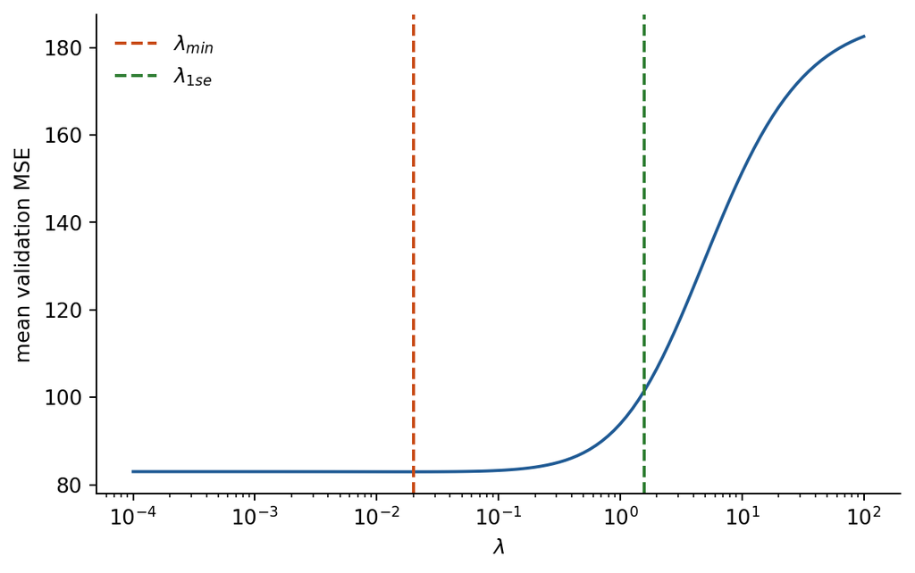

Mean validation MSE across the penalty grid.

```python
fold_ids = sorted(np.unique(folds))
err = np.zeros((len(fold_ids), len(grid)))
for fi, f in enumerate(fold_ids):
    trn, val = folds != f, folds == f
    Xf, yf = Xtr_all[trn], ytr_all[trn]
    Xv, yv = Xtr_all[val], ytr_all[val]
    mu, sd = scale_of(Xf)
    Xfs, Xvs = (Xf - mu) / sd, (Xv - mu) / sd
    ybar = yf.mean(); yt = yf - ybar
    for li, lam in enumerate(grid):
        b = ridge(Xfs, yt, lam, len(yf))
        err[fi, li] = np.mean((yv - (ybar + Xvs @ b)) ** 2)

mean_mse = err.mean(0)
se = err.std(0, ddof=1) / np.sqrt(len(fold_ids))
imin = int(np.argmin(mean_mse))
lam_min = grid[imin]
lam_1se = grid[mean_mse <= mean_mse[imin] + se[imin]].max()
print(f"lambda_min = {lam_min:.5g}   (mean MSE {mean_mse[imin]:.2f}, SE {se[imin]:.2f})")
print(f"lambda_1se = {lam_1se:.5g}")

plt.figure(figsize=(7, 4.2))
plt.plot(grid[1:], mean_mse[1:], color="#1F5A94")
plt.axvline(lam_min, color="#C84A16", ls="--", label=r"$\lambda_{min}$")
plt.axvline(lam_1se, color="#2E7D32", ls="--", label=r"$\lambda_{1se}$")
plt.xscale("log"); plt.xlabel(r"$\lambda$"); plt.ylabel("mean validation MSE")
plt.legend(frameon=False); plt.gca().spines[["top", "right"]].set_visible(False)
plt.show()
```

CV picks $\lambda_{\min} \approx 0.020$. The one-SE rule then takes the largest penalty whose mean MSE is still within one SE of the minimum, which is $\lambda_{\mathrm{1se}} \approx 1.585$, a much more aggressive shrinkage that CV considers statistically indistinguishable from the best.

**b.** GCV on all 332 training observations, means and scales fixed once.

**Show the workflow**

```
lambda_GCV = 0.028184
```

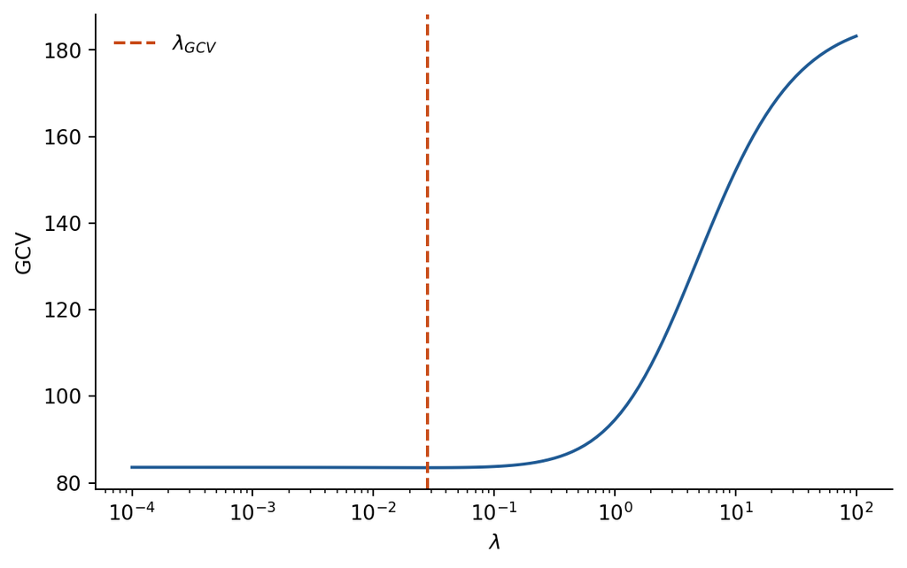

GCV criterion across the penalty grid.

```python
mu, sd = scale_of(Xtr_all)
Xs = (Xtr_all - mu) / sd
ybar = ytr_all.mean(); yt = ytr_all - ybar
svals = np.linalg.svd(Xs, compute_uv=False)

gcv = np.empty(len(grid))
for li, lam in enumerate(grid):
    b = ridge(Xs, yt, lam, n_all)
    mse_tr = np.mean((yt - Xs @ b) ** 2)
    dfeff = 1 + np.sum(svals ** 2 / (svals ** 2 + n_all * lam))
    gcv[li] = mse_tr / (1 - dfeff / n_all) ** 2
lam_gcv = grid[int(np.argmin(gcv))]
print(f"lambda_GCV = {lam_gcv:.5g}")

plt.figure(figsize=(7, 4.2))
plt.plot(grid[1:], gcv[1:], color="#1F5A94")
plt.axvline(lam_gcv, color="#C84A16", ls="--", label=r"$\lambda_{GCV}$")
plt.xscale("log"); plt.xlabel(r"$\lambda$"); plt.ylabel("GCV")
plt.legend(frameon=False); plt.gca().spines[["top", "right"]].set_visible(False)
plt.show()
```

GCV lands at $\lambda_{\mathrm{GCV}} \approx 0.028$, close to $\lambda_{\min}$. That makes sense: both are chasing prediction error, just with different machinery (out-of-fold error vs a training-error correction), so they end up near the same light penalty.

**c.** With all three penalties fixed, refit on all training data and only now touch the test responses.

**Show the workflow**

```python
def dfeff_of(lam):
    return 1 + np.sum(svals ** 2 / (svals ** 2 + n_all * lam))

Xtes = (Xte - mu) / sd
print(f"{'model':<11}{'lambda':>10}{'trainMSE':>11}{'testMSE':>10}{'dfeff':>8}")
for name, lam in [("OLS", 0.0), ("ridge_min", lam_min),
                  ("ridge_1se", lam_1se), ("ridge_GCV", lam_gcv)]:
    b = ridge(Xs, yt, lam, n_all)
    tr_mse = np.mean((yt - Xs @ b) ** 2)
    te_mse = np.mean((yte - (ybar + Xtes @ b)) ** 2)
    print(f"{name:<11}{lam:>10.4g}{tr_mse:>11.2f}{te_mse:>10.2f}{dfeff_of(lam):>8.2f}")
```

```
model          lambda   trainMSE   testMSE   dfeff
OLS                 0      80.09     66.32    7.00
ridge_min     0.01995      80.14     66.00    6.77
ridge_1se       1.585     100.37     81.20    3.03
ridge_GCV     0.02818      80.17     65.90    6.69
```

OLS, ridge at $\lambda_{\min}$, and ridge at $\lambda_{\mathrm{GCV}}$ all sit near the same place: training MSE around $80$, test MSE around $66$, and effective df close to the full $7$. The light penalties barely change anything here, which fits with the earlier plots showing a flat MSE curve near the minimum. Ridge at $\lambda_{\mathrm{1se}}$ is the outlier: it drops effective df to about $3$, so it’s a much simpler model, and both its training and test MSE are higher. That’s the bias-variance tradeoff in action, the heavy shrinkage bought stability the data here didn’t actually need, so it paid in accuracy.

Even though one row has the lowest test MSE, I can’t go back and pick it on that basis. The test set was only supposed to give one honest readout of a model chosen beforehand. If I let the observed test numbers decide among the four, the test set becomes part of selection and its error estimate stops being unbiased, the same reason a validation set gets used up once you tune on it. The legitimate choice was locked in before this table using CV and GCV.

## `explain-to-me` skill

Below is the complete `explain-to-me/SKILL.md` I built and installed for Question 1.

```markdown
---
name: explain-to-me
description: >
  Use when I ask you to "use explain-to-me" on a homework question. Explain
  what the question is actually asking and point me to the right lecture
  section. Do NOT solve it, write code for it, or give the answer.
---

# explain-to-me

## My intent
I want to understand a homework question before I attempt it myself. Your job
is to unpack the question, not to do it. Treat solving it as off-limits even
if I seem stuck or ask indirectly.

## What to do
1. Restate the question in plain language: what is the goal, in one or two
   sentences.
2. List the concrete deliverables (what I actually have to produce or report),
   as a short checklist.
3. Flag the key concept being tested and name any assumptions or setup that
   are easy to miss (seeds, scaling conventions, what counts as a parameter).
4. Point me to the relevant Week 3 lecture section by name and link:
   - Ridge Regression: Stability Through Shrinkage
     https://teazrq.github.io/stat432rpy/topics/ridge-regression/ridge-regression.html
   - From a Penalized Objective to a Fitted Ridge Model
     https://teazrq.github.io/stat432rpy/topics/ridge-regression/optimization-and-cross-validation.html
5. If useful, suggest what to review first, but stop before any derivation,
   formula rearrangement, code, or numeric answer.

## What NOT to do
- Do not derive results, write or debug code, or state final answers.
- Do not compute values, even as an "example."
- If I push for the solution, remind me the skill is only for explaining, and
  point me to the lecture instead.

## Style
Be brief and concrete. Prefer a short checklist over long paragraphs.
```

## Reference

The real-estate data come from I-Cheng Yeh’s [Real Estate Valuation dataset](https://archive.ics.uci.edu/dataset/477/real%2Bestate%2Bvaluation%2Bda) in the UCI Machine Learning Repository. The distributed data retain the original observations and add only the course train-test and fold assignments.